# Descriptive Finding Assignment

Manuel Wüthrich

4/20/2020

# Histogram of Government Types in 2017

This tiny descriptive research shows different government types among 36 OECD and/or EU-members in the year 2017 based on the comparative political data set (CPDS, Armingeon (2019)). They describe seven different government types, however there were no caretaker or technocratic governments in 2017, so we focus only on five of them.

- 1 Single-party majority government: One party takes all governments seats and has a parliamentary majority [>50.0%].
- 2 Minimal winning coalition: All participating parties are necessary to form a majority government [>50.0%].
- 3 Surplus coalition: Coalition governments which exceed the minimal-winning criterion [>50.0%].
- 4 Single-party minority government: The party in government does not possess a majority in Parliament [≤50.0%].
- 5 Multi-party minority government: The parties in government do not possess a majority in Parliament [≤50.0%].

The following histogram shows which government type was the most common in 2017. Therefore, we can say the most common government type among those 36 countries are coalitions (2 and 3).

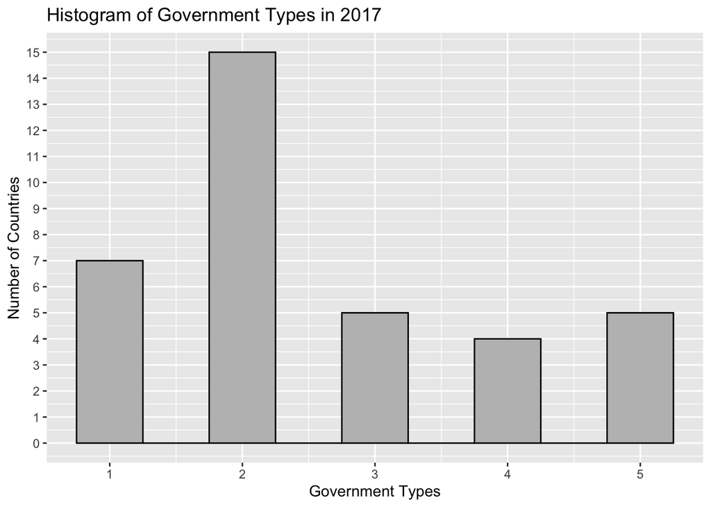

Armingeon, Klaus. 2019. *Comparative Political Data Set 1960-2017*. Zurich: Institute of Political Science, University of Zurich.